# model.rmd

Daniel Karstad

Maren Sognefest

# Modeller

## Leser inn data

```r
pm2 <- read_csv("data/pm2.csv", show_col_types = FALSE)
```

Vi er ute etter fylkesnummeret, for å lage en ny fylke faktorvariabel. (De to første siffrene i kommunenummeret). Vi bruker mutate() som funksjon for å hente ut deler av en tekststreng. Lager også en faktorvariabel fra årsvariabelen. Og skalerer variabelen Trade_pc.

```r
pm2 <- pm2 %>%
  mutate(
    fnr = (str_sub(knr, 1,2))
  )
```

```r
pm2 <- pm2 %>%
  mutate(
    fnr = parse_factor(fnr, levels = fnr),
    aar_f = parse_factor(as.character(aar))
  )
```

```r
pm2 <- pm2 %>%mutate(Trade_pc_100K = trade_pc/100000)
```

```r
head(pm2, n = 4)
```

| knr | knavn | aar | pm2 | ya_menn | ya_kvinner | ya_total | inc_k1 | inc_k5 | uni_k_mf | uni_k_m | uni_k_f | uni_l_mf | uni_l_m | uni_l_f | trade_pc | fnr | aar_f | Trade_pc_100K |
| --- | --- | --- | --- | --- | --- | --- | --- | --- | --- | --- | --- | --- | --- | --- | --- | --- | --- | --- |
| 0101 | Halden | 2008 | 13427 | 59.74892 | 56.79763 | 58.26214 | 24.5 | 13.6 | 17.8 | 15.1 | 20.4 | 3.9 | 5.4 | 2.4 | 56266 | 01 | 2008 | 0.56266 |
| 0101 | Halden | 2009 | 13095 | 59.77860 | 57.04693 | 58.40290 | 24.4 | 14.1 | 18.2 | 15.4 | 20.9 | 3.9 | 5.4 | 2.5 | 56366 | 01 | 2009 | 0.56366 |
| 0101 | Halden | 2010 | 13832 | 59.64298 | 57.06300 | 58.34376 | 23.9 | 13.7 | 18.6 | 15.6 | 21.6 | 4.1 | 5.5 | 2.7 | 57210 | 01 | 2010 | 0.57210 |
| 0101 | Halden | 2011 | 14915 | 59.84630 | 57.22382 | 58.53183 | 24.0 | 14.0 | 19.0 | 15.8 | 22.2 | 4.4 | 5.8 | 3.0 | 58010 | 01 | 2011 | 0.58010 |

##Modell

```r
mod1 <- 'pm2 ~ aar_f + ya_total + inc_k1 + inc_k5 + uni_k_mf + uni_l_mf + Trade_pc_100K'
```

### i.Generer et lm objekt (lm1) utfra mod1 og datasettet pm2.

```r
lm1 <- lm(mod1, data = pm2)
```

```r
lm1 %>%
  summary()
```

```
##
## Call:
## lm(formula = mod1, data = pm2)
##
## Residuals:
##     Min      1Q  Median      3Q     Max
## -9089.8 -1525.7    -0.9  1526.2 16322.2
##
## Coefficients:
##                Estimate Std. Error t value Pr(>|t|)
## (Intercept)   -23574.01    2293.29 -10.280  < 2e-16 ***
## aar_f2009        235.79     237.53   0.993 0.320967
## aar_f2010        856.73     236.16   3.628 0.000291 ***
## aar_f2011       1573.77     233.50   6.740 1.94e-11 ***
## aar_f2012       2147.08     232.51   9.234  < 2e-16 ***
## aar_f2013       2696.89     233.74  11.538  < 2e-16 ***
## aar_f2014       2690.92     236.01  11.402  < 2e-16 ***
## aar_f2015       3273.99     236.74  13.830  < 2e-16 ***
## aar_f2016       3935.87     240.54  16.363  < 2e-16 ***
## aar_f2017       4750.67     241.87  19.641  < 2e-16 ***
## ya_total         640.19      33.87  18.902  < 2e-16 ***
## inc_k1          -380.90      25.34 -15.030  < 2e-16 ***
## inc_k5           198.36      19.24  10.309  < 2e-16 ***
## uni_k_mf        -122.68      27.26  -4.501 7.06e-06 ***
## uni_l_mf        1262.10      40.27  31.340  < 2e-16 ***
## Trade_pc_100K   1184.06     205.44   5.764 9.19e-09 ***
## ---
## Signif. codes:  0 '***' 0.001 '**' 0.01 '*' 0.05 '.' 0.1 ' ' 1
##
## Residual standard error: 2611 on 2649 degrees of freedom
## Multiple R-squared:  0.8196, Adjusted R-squared:  0.8186
## F-statistic: 802.5 on 15 and 2649 DF,  p-value: < 2.2e-16
```

### ii. Legg residualene fra den lineære modellen til datasettet pm2.

```r
pm2 <- pm2 %>%
  add_residuals(lm1)
```

## Test for heteroskedastisitet

### i.

```r
bptest(lm1)
```

```
##
##  studentized Breusch-Pagan test
##
## data:  lm1
## BP = 315.98, df = 15, p-value < 2.2e-16
```

### ii.

```r
library(gvlma)
gvlma(lm1)
```

```
##
## Call:
## lm(formula = mod1, data = pm2)
##
## Coefficients:
##   (Intercept)      aar_f2009      aar_f2010      aar_f2011      aar_f2012
##      -23574.0          235.8          856.7         1573.8         2147.1
##     aar_f2013      aar_f2014      aar_f2015      aar_f2016      aar_f2017
##        2696.9         2690.9         3274.0         3935.9         4750.7
##      ya_total         inc_k1         inc_k5       uni_k_mf       uni_l_mf
##         640.2         -380.9          198.4         -122.7         1262.1
## Trade_pc_100K
##        1184.1
##
##
## ASSESSMENT OF THE LINEAR MODEL ASSUMPTIONS
## USING THE GLOBAL TEST ON 4 DEGREES-OF-FREEDOM:
## Level of Significance =  0.05
##
## Call:
##  gvlma(x = lm1)
##
##                     Value   p-value                   Decision
## Global Stat        871.80 0.000e+00 Assumptions NOT satisfied!
## Skewness            65.91 4.441e-16 Assumptions NOT satisfied!
## Kurtosis           691.06 0.000e+00 Assumptions NOT satisfied!
## Link Function       84.17 0.000e+00 Assumptions NOT satisfied!
## Heteroscedasticity  30.66 3.077e-08 Assumptions NOT satisfied!
```

### iii.

```r
coeftest(lm1, vcov = vcovHC(lm1, type = "HC3"))
```

```
##
## t test of coefficients:
##
##                 Estimate Std. Error  t value  Pr(>|t|)
## (Intercept)   -23574.015   2526.378  -9.3312 < 2.2e-16 ***
## aar_f2009        235.786    203.381   1.1593 0.2464254
## aar_f2010        856.728    194.239   4.4107 1.072e-05 ***
## aar_f2011       1573.772    198.548   7.9264 3.294e-15 ***
## aar_f2012       2147.080    212.046  10.1255 < 2.2e-16 ***
## aar_f2013       2696.888    207.517  12.9960 < 2.2e-16 ***
## aar_f2014       2690.915    217.566  12.3683 < 2.2e-16 ***
## aar_f2015       3273.988    231.201  14.1608 < 2.2e-16 ***
## aar_f2016       3935.865    249.553  15.7717 < 2.2e-16 ***
## aar_f2017       4750.672    265.244  17.9106 < 2.2e-16 ***
## ya_total         640.195     37.917  16.8841 < 2.2e-16 ***
## inc_k1          -380.905     25.433 -14.9768 < 2.2e-16 ***
## inc_k5           198.359     22.263   8.9099 < 2.2e-16 ***
## uni_k_mf        -122.684     34.785  -3.5270 0.0004275 ***
## uni_l_mf        1262.100     69.257  18.2233 < 2.2e-16 ***
## Trade_pc_100K   1184.061    218.171   5.4272 6.242e-08 ***
## ---
## Signif. codes:  0 '***' 0.001 '**' 0.01 '*' 0.05 '.' 0.1 ' ' 1
```

### iv.

```r
pm2 <- pm2 %>%
  add_residuals(lm1)
```

### v.

```r
pm2 <- pm2 %>%
  mutate(aar_d =make_date(aar))
```

### vi.

```r
pm2 <- pm2 %>%
  mutate(fylke = substr(knr, start = 1, stop = 2))
```

### vii + viii + ix + x

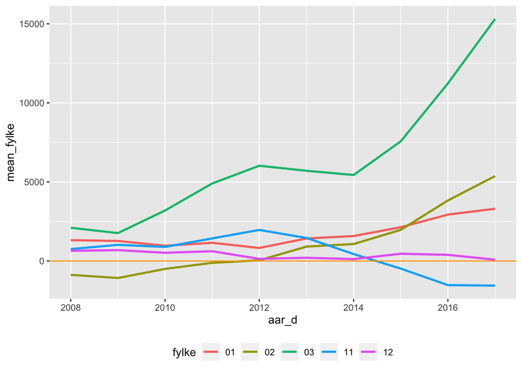

```r
pm2 %>%
  filter(fylke %in% c("01", "02", "03", "11", "12")) %>%
  unnest(c(fylke)) %>%
  group_by(fylke, aar_d) %>%
  summarize(mean_fylke = mean(resid)
            ) %>%
  ggplot(aes(x = aar_d, y = mean_fylke, colour = fylke)) +
  geom_line(lwd=1) +
  theme(legend.position = "bottom")+
  geom_hline(yintercept = 0, colour = "orange")
```

# Dummy fylke og år

### i + ii.

Her infører vi en dummy for hvert fylke hvert år. + Genererer lm2 fra modell 2 og datasettet pm2.

```r
mod2 <- 'pm2 ~ aar_f*fnr + ya_total + inc_k1 + inc_k5 + uni_k_mf + uni_l_mf + Trade_pc_100K'
lm2 <- lm(mod2, data = pm2)
summary(lm2)
```

```
##
## Call:
## lm(formula = mod2, data = pm2)
##
## Residuals:
##     Min      1Q  Median      3Q     Max
## -7923.8 -1315.5    16.7  1307.7 13524.6
##
## Coefficients:
##                   Estimate Std. Error t value Pr(>|t|)
## (Intercept)     -21008.194   2229.110  -9.424  < 2e-16 ***
## aar_f2009          117.254    779.646   0.150 0.880466
## aar_f2010          427.365    791.428   0.540 0.589252
## aar_f2011         1290.937    791.696   1.631 0.103103
## aar_f2012         1475.509    792.404   1.862 0.062712 .
## aar_f2013         2518.738    792.973   3.176 0.001510 **
## aar_f2014         2755.249    782.555   3.521 0.000438 ***
## aar_f2015         3823.769    782.737   4.885 1.10e-06 ***
## aar_f2016         5286.236    795.176   6.648 3.65e-11 ***
## aar_f2017         6448.890    783.851   8.227 3.06e-16 ***
## fnr02            -1576.497    745.081  -2.116 0.034455 *
## fnr03             2858.301   2325.006   1.229 0.219049
## fnr04             -993.568    822.150  -1.208 0.226971
## fnr05            -1836.135    792.893  -2.316 0.020654 *
## fnr06            -2065.423    770.483  -2.681 0.007396 **
## fnr07             -647.551   1148.302  -0.564 0.572859
## fnr08            -3331.237    878.035  -3.794 0.000152 ***
## fnr09            -1665.045    903.551  -1.843 0.065481 .
## fnr10             -336.884    879.838  -0.383 0.701832
## fnr11             -750.142    772.929  -0.971 0.331883
## fnr12            -1106.505    768.237  -1.440 0.149905
## fnr14            -3038.500   1019.569  -2.980 0.002909 **
## fnr15            -3457.883    758.964  -4.556 5.47e-06 ***
## fnr16            -1190.346    793.732  -1.500 0.133825
## fnr17            -2715.149    858.902  -3.161 0.001590 **
## fnr18            -1485.901    822.635  -1.806 0.070998 .
## fnr19            -3255.562   1253.077  -2.598 0.009431 **
## fnr20            -2725.899   1074.474  -2.537 0.011243 *
## ya_total           527.285     32.099  16.427  < 2e-16 ***
## inc_k1            -271.324     23.167 -11.711  < 2e-16 ***
```

[output cut: 157 more lines]

```
## aar_f2009:fnr20  -1033.459   1564.091  -0.661 0.508840
## aar_f2010:fnr20   -429.231   1569.873  -0.273 0.784555
## aar_f2011:fnr20   -916.024   1570.019  -0.583 0.559645
## aar_f2012:fnr20   -300.249   1648.151  -0.182 0.855462
## aar_f2013:fnr20  -1072.631   1648.536  -0.651 0.515328
## aar_f2014:fnr20  -1324.069   1564.804  -0.846 0.397548
## aar_f2015:fnr20  -2197.055   1564.890  -1.404 0.160454
## aar_f2016:fnr20  -1780.031   1515.941  -1.174 0.240425
## aar_f2017:fnr20  -3151.542   1564.756  -2.014 0.044109 *
## ---
## Signif. codes:  0 '***' 0.001 '**' 0.01 '*' 0.05 '.' 0.1 ' ' 1
##
## Residual standard error: 2238 on 2469 degrees of freedom
## Multiple R-squared:  0.8765, Adjusted R-squared:  0.8667
## F-statistic: 89.86 on 195 and 2469 DF,  p-value: < 2.2e-16
```

### iii.

Legger residualene fra lm2 til pm2 og kaller dem res_m2.

```r
pm2 <- pm2 %>%
  mutate(res_m2 = resid(lm2))
```

### iv.

Lager del-plott for hvert fylke.

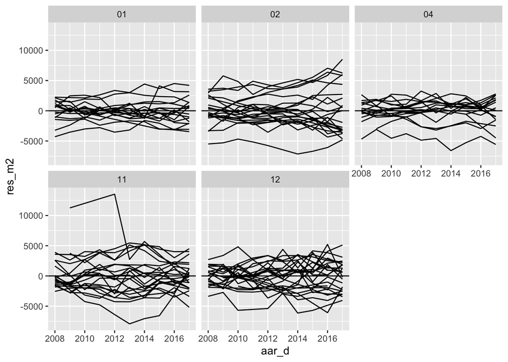

```r
pm2 %>% filter(fnr %in% c("01", "02", "04", "11", "12")) %>%
ggplot(mapping = aes(x = aar_d, y = res_m2)) +
geom_line(aes(group = knavn)) +
scale_size_manual(values = c(seq(2.0, 0.5, by = -0.1))) +
geom_hline(yintercept = 0) +
theme(legend.position = 'bottom') +
  facet_wrap(~fylke)
```

### i.

Kvaliteten på modellen er ikke optimal, ettersom den har noen manglende variabler. Det er stor variasjon, noe som kan være forårsaket av heteroskedastisitet i modellen.

### ii.

Ja, det er grunn til å mistenke at vi mangler viktige variabler i modell 2.

### iii.

Filtrert med hensyn på fylke “11”.

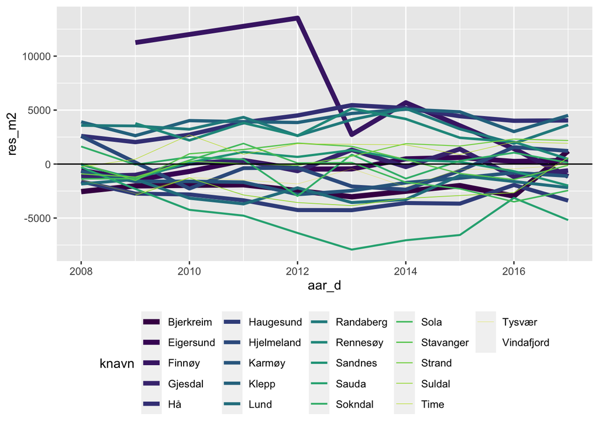

```r
pm2 %>% filter(fnr %in% c("11")) %>%
ggplot(mapping = aes(x = aar_d, y = res_m2)) +
scale_color_viridis(discrete = TRUE, option = "D") +
geom_line(aes(group = knavn, colour = knavn, size =knavn)) +
scale_size_manual(values = c(seq(2.1, 0, by = -0.1))) +
geom_hline(yintercept = 0) +
theme(legend.position = 'bottom')
```

### i.

Gjentar plottet ovenfor men med sortering for enkelte kommuner.

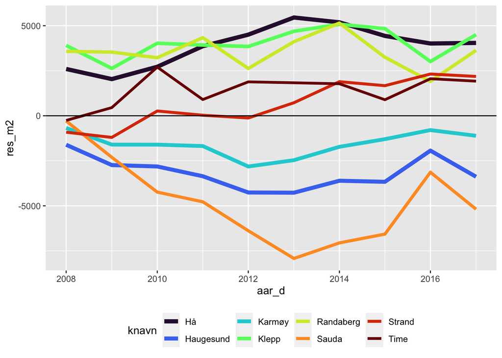

```r
pm2 %>% filter(knr %in% c("1119", "1120", "1127", "1121", "1130", "1135", "1106", "1149")) %>%
ggplot(mapping = aes(x = aar_d, y = res_m2)) +
scale_color_viridis(discrete = TRUE, option = "H") +
geom_line(aes(group = knavn, colour = knavn, size =knavn)) +
scale_size_manual(values = c(seq(2.0, 0.5, by = -0.1))) +
geom_hline(yintercept = 0) +
theme(legend.position = 'bottom')
```

### ii.

Feil! Modelen undervurderer prisen derfor positiv residual.

# Modell for hvert år

### i.

```r
pm2 <- pm2 %>%
  mutate(
    aar_d = date(paste0(aar, "-01-01"))
  )
```

```r
pm2_n <- pm2 %>%
  select(pm2, fnr, knr, aar_d, aar, aar_f, ya_menn, ya_kvinner, ya_total, inc_k1, inc_k5, uni_k_mf, uni_l_mf, Trade_pc_100K) %>%
  group_by(aar_d) %>%
  nest()
```

```r
pm2_n
```

| aar_d | data |
| --- | --- |
| 2008-01-01 |  |
| 2009-01-01 |  |
| 2010-01-01 |  |
| 2011-01-01 |  |
| 2012-01-01 |  |
| 2013-01-01 |  |
| 2014-01-01 |  |
| 2015-01-01 |  |
| 2016-01-01 |  |
| 2017-01-01 |  |

```r
pm2_n$data[[1]] %>%
head(n = 5)
```

| pm2 | fnr | knr | aar | aar_f | ya_menn | ya_kvinner | ya_total | inc_k1 | inc_k5 | uni_k_mf | uni_l_mf | Trade_pc_100K |
| --- | --- | --- | --- | --- | --- | --- | --- | --- | --- | --- | --- | --- |
| 13427 | 01 | 0101 | 2008 | 2008 | 59.74892 | 56.79763 | 58.26214 | 24.5 | 13.6 | 17.8 | 3.9 | 0.56266 |
| 18299 | 01 | 0104 | 2008 | 2008 | 60.69851 | 58.67423 | 59.66705 | 22.8 | 16.2 | 19.1 | 5.5 | 0.69916 |
| 14981 | 01 | 0105 | 2008 | 2008 | 60.89855 | 58.06389 | 59.47153 | 22.2 | 13.6 | 16.3 | 2.8 | 0.63674 |
| 15671 | 01 | 0106 | 2008 | 2008 | 59.81091 | 57.82070 | 58.79460 | 21.8 | 16.2 | 19.0 | 4.3 | 0.69040 |
| 18844 | 01 | 0111 | 2008 | 2008 | 61.67247 | 61.27049 | 61.47438 | 17.8 | 19.0 | 18.3 | 4.7 | 0.75027 |

### i.

Funksjonen *kom_model* for å kjøre hvert enkelt år:

```r
kom_model <- function(a_df) {
  lm(pm2 ~ fnr + ya_total + inc_k1 + inc_k5 + uni_k_mf + uni_l_mf + Trade_pc_100K, data = a_df)
}
```

### i.

```r
pm2_n <- pm2_n %>%
  mutate(
    model = map(data, .f = kom_model)
    )
```

```r
# summary 2008
pm2_n$model[[1]] %>%
  summary()
```

```
##
## Call:
## lm(formula = pm2 ~ fnr + ya_total + inc_k1 + inc_k5 + uni_k_mf +
##     uni_l_mf + Trade_pc_100K, data = a_df)
##
## Residuals:
##     Min      1Q  Median      3Q     Max
## -4654.7 -1159.6   108.5  1074.2  4907.5
##
## Coefficients:
##                Estimate Std. Error t value Pr(>|t|)
## (Intercept)   -19995.26    5886.89  -3.397 0.000812 ***
## fnr02             94.71     661.30   0.143 0.886251
## fnr03           4409.33    2011.32   2.192 0.029429 *
## fnr04          -1846.50     670.37  -2.754 0.006380 **
## fnr05          -2384.11     638.14  -3.736 0.000239 ***
## fnr06          -1791.29     619.59  -2.891 0.004231 **
## fnr07           -452.89     921.19  -0.492 0.623476
## fnr08          -3705.14     705.30  -5.253 3.57e-07 ***
## fnr09          -1867.00     726.18  -2.571 0.010812 *
## fnr10           -422.80     723.49  -0.584 0.559570
## fnr11            201.24     697.48   0.289 0.773227
## fnr12           -562.95     668.02  -0.843 0.400325
## fnr14          -2970.92     849.89  -3.496 0.000574 ***
## fnr15          -3270.48     665.51  -4.914 1.76e-06 ***
## fnr16          -1398.42     646.10  -2.164 0.031531 *
## fnr17          -3260.93     713.61  -4.570 8.21e-06 ***
## fnr18          -2036.75     681.74  -2.988 0.003137 **
## fnr19          -3524.96    1004.86  -3.508 0.000549 ***
## fnr20          -3077.48     873.75  -3.522 0.000522 ***
## ya_total         467.07      85.56   5.459 1.31e-07 ***
## inc_k1          -116.06      65.47  -1.773 0.077714 .
## inc_k5           191.86      53.09   3.614 0.000375 ***
## uni_k_mf         191.90      74.65   2.571 0.010822 *
## uni_l_mf         606.16     126.96   4.774 3.32e-06 ***
## Trade_pc_100K   1338.87     513.05   2.610 0.009699 **
## ---
## Signif. codes:  0 '***' 0.001 '**' 0.01 '*' 0.05 '.' 0.1 ' ' 1
##
## Residual standard error: 1768 on 216 degrees of freedom
## Multiple R-squared:  0.8652, Adjusted R-squared:  0.8502
## F-statistic: 57.76 on 24 and 216 DF,  p-value: < 2.2e-16
```

### i.

Funksjonen *glance* + *mod_summary* og *unnest ()*

```r
pm2_n %>%
  filter(aar_d == "2008-01-01") %>%
  .$model %>%
  map_df(glance)
```

| r.squared | adj.r.squared | sigma | statistic | p.value | df | logLik | AIC | BIC | deviance | df.residual | nobs |
| --- | --- | --- | --- | --- | --- | --- | --- | --- | --- | --- | --- |
| 0.8651805 | 0.8502005 | 1767.79 | 57.75592 | 2.245446e-80 | 24 | -2130.841 | 4313.682 | 4404.287 | 675017800 | 216 | 241 |

```r
mod_sum <- pm2_n %>%
  mutate(mod_summary = map(.x = model, .f = glance)) %>%
  unnest(mod_summary) %>%
  print()
```

```
## # A tibble: 10 × 15
## # Groups:   aar_d [10]
##    aar_d      data       model r.squared adj.r.squared sigma statistic   p.value
##    <date>     <list>     <lis>     <dbl>         <dbl> <dbl>     <dbl>     <dbl>
##  1 2008-01-01 <tibble [… <lm>      0.865         0.850 1768.      57.8 2.25e- 80
##  2 2009-01-01 <tibble [… <lm>      0.857         0.841 1867.      54.2 2.66e- 78
##  3 2010-01-01 <tibble [… <lm>      0.876         0.862 1842.      66.0 5.80e- 88
##  4 2011-01-01 <tibble [… <lm>      0.873         0.861 2023.      69.0 1.45e- 93
##  5 2012-01-01 <tibble [… <lm>      0.848         0.834 2302.      58.4 1.70e- 88
##  6 2013-01-01 <tibble [… <lm>      0.884         0.873 2095.      79.7 9.97e-103
##  7 2014-01-01 <tibble [… <lm>      0.862         0.849 2308.      64.5 2.02e- 92
##  8 2015-01-01 <tibble [… <lm>      0.868         0.855 2438.      70.9 1.20e- 99
##  9 2016-01-01 <tibble [… <lm>      0.871         0.859 2535.      70.5 3.01e- 97
## 10 2017-01-01 <tibble [… <lm>      0.877         0.865 2703.      75.7 7.97e-102
## # … with 7 more variables: df <dbl>, logLik <dbl>, AIC <dbl>, BIC <dbl>,
## #   deviance <dbl>, df.residual <int>, nobs <int>
```

### i.

Ny variabel av type date i *coef_df* som angir år.

```r
coef_df <- mod_sum$model %>%
  map_df(1) %>%
  tibble()
```

```r
coef_df <- coef_df %>%
  mutate(
    aar = ymd(paste(2008:2017, "-01-01", sep = ""))
  ) %>%
  select(aar, everything())
```

### ii.

Bruk pivot_longer på *coef_df* for å gjøre om til *coef_df_long*

```r
coef_df_long <- coef_df %>%
  pivot_longer(
    cols = `(Intercept)`:`Trade_pc_100K`,
    names_to = "variables",
    values_to = "coef")
```

### iii.

Lager så et plot av fylke-faktorvariablenes koeffisienter ved bruk av *coef_df_long*.

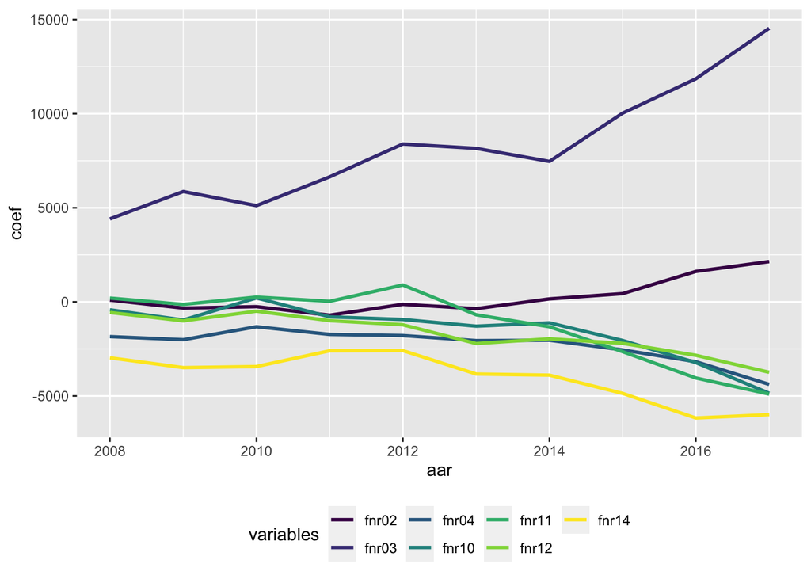

```r
coef_df_long %>%
  select(aar, variables, coef) %>%
  filter(
    variables %in% c("fnr02", "fnr03", "fnr04", "fnr10", "fnr11", "fnr12", "fnr14")
  ) %>%
  ggplot(mapping = aes(x = aar, y = coef, colour = variables)) +
  scale_color_viridis(discrete = TRUE, option = "D") +
  geom_line(aes(group = variables), lwd = 1) +
  theme(legend.position = 'bottom')
```

### v.

I 2014 gikk vi gjennom en oljekrise. Oljeprisen gikk fra 114 dollar fatet til under 30 usd på et halvt år. Norsk økonomi som er veldig avhengig av olje og norske kronen som er veldig avhengig av oljeprisen gikk dermed inn i en nedgangskonjuktur. Derav fikk vi mange oppsigelser direkte i oljerelaterte næringer men også økende arbeidsledighet generelt. Dette rammet særlig områder som har høy tetthet av oljerelatert næring, for eksempel Stavanger-regionen. Noe som forårsaket en negativ boligpris utvikling og generelt lavere attraktivitet for hele området.

### i.

Lage et tilsvarende plot, med nye variabler.

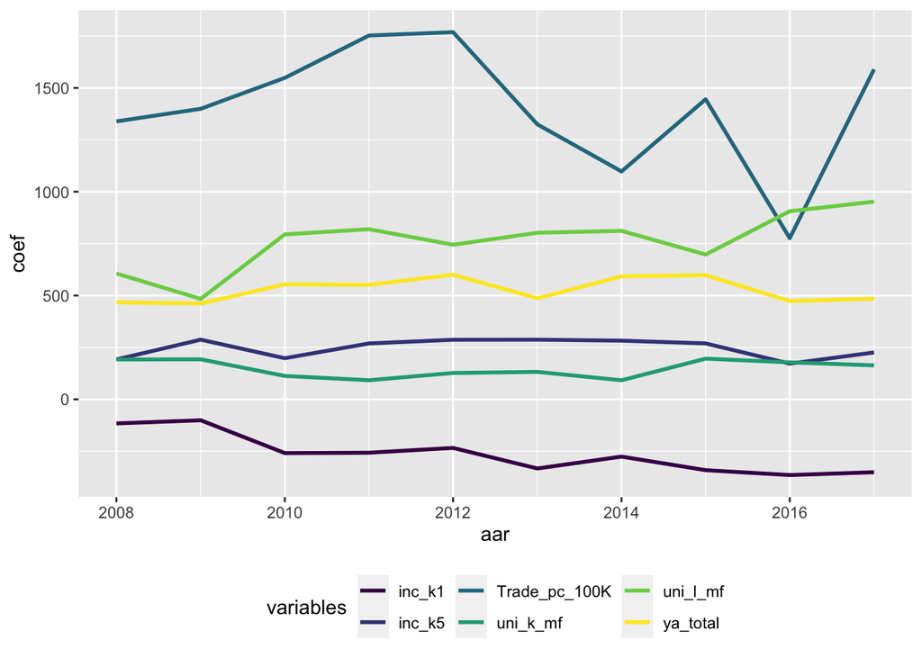

```r
coef_df_long %>%
select(aar, variables, coef) %>%
filter(
variables %in% c("ya_total", "inc_k1", "inc_k5", "uni_k_mf", "uni_l_mf", "Trade_pc_100K")
) %>%
ggplot(mapping = aes(x = aar, y = coef, colour = variables)) +
scale_color_viridis(discrete = TRUE, option = "D") +
geom_line(aes(group = variables), lwd = 1) +
theme(legend.position = 'bottom')
```

### ii.

```r
#siste
```